# G1401231094_Kamal Aldimas_Tugas MPDW

2025-09-01

```r
library(readxl)
library(rio)
library("forecast")
```

```r
library("graphics")
library("TTR")
library(ggplot2)
```

# Import Data

```r
kurs<- read_excel("C:/Users/Kamal Aldimas/Downloads/SEMESTER 5/MPDW/Kurs Jual Rataan USD Fix.xlsx")
kurs
```

```
## # A tibble: 518 × 2
##    `Minggu Ke-` `Kurs Jual Rataan`
##           <dbl>              <dbl>
##  1            1             12723
##  2            2             12689.
##  3            3             12671.
##  4            4             12543.
##  5            5             12682.
##  6            6             12721
##  7            7             12837.
##  8            8             12919.
##  9            9             13025.
## 10           10             13151.
## # ℹ 508 more rows
```

```r
data <- kurs[416:518,]
data
```

```
## # A tibble: 103 × 2
##    `Minggu Ke-` `Kurs Jual Rataan`
##           <dbl>              <dbl>
##  1          416             14953.
##  2          417             15056.
##  3          418             15070.
##  4          419             15160.
##  5          420             15110.
##  6          421             15084.
##  7          422             15141.
##  8          423             15265.
##  9          424             15337.
## 10          425             15395.
## # ℹ 93 more rows
```

```r
data.ts <- ts(data$`Kurs Jual Rataan`)
```

# Eksplorasi Data

```r
summary(data.ts)
```

```
##    Min. 1st Qu.  Median    Mean 3rd Qu.    Max.
##   14953   15585   15955   15950   16356   16933
```

membuat plot data deret waktu

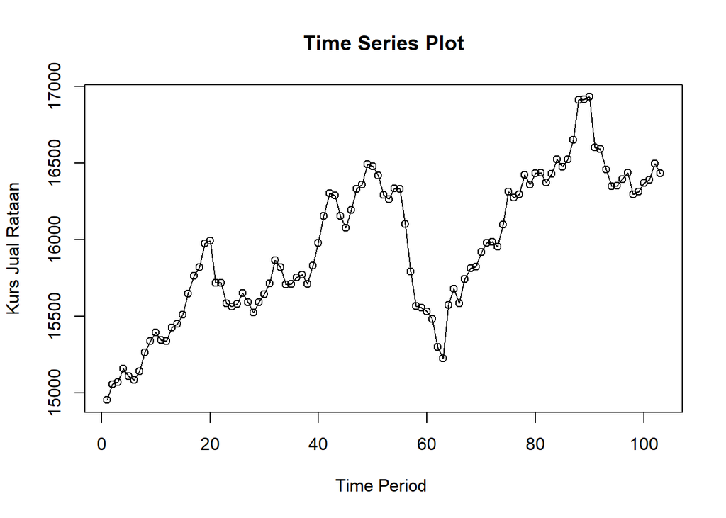

```r
ts.plot(data.ts, xlab="Time Period ", ylab="Kurs Jual Rataan",
        main = "Time Series Plot")
points(data.ts)
```

# Single Moving Average

pembagian data latih dan data uji dilakukan dengan perbandingan 80% data latih dan 20% data uji

```r
# hitung jumlah data
n <- nrow(data)

# tentukan batas 80%
n_train <- floor(0.8 * n)

# bagi data
training_ma <- data[1:n_train, ]
testing_ma  <- data[(n_train+1):n, ]

# ubah ke time series
train_ma.ts <- ts(training_ma$`Kurs Jual Rataan`)
test_ma.ts  <- ts(testing_ma$`Kurs Jual Rataan`)
```

eksplorasi data latih

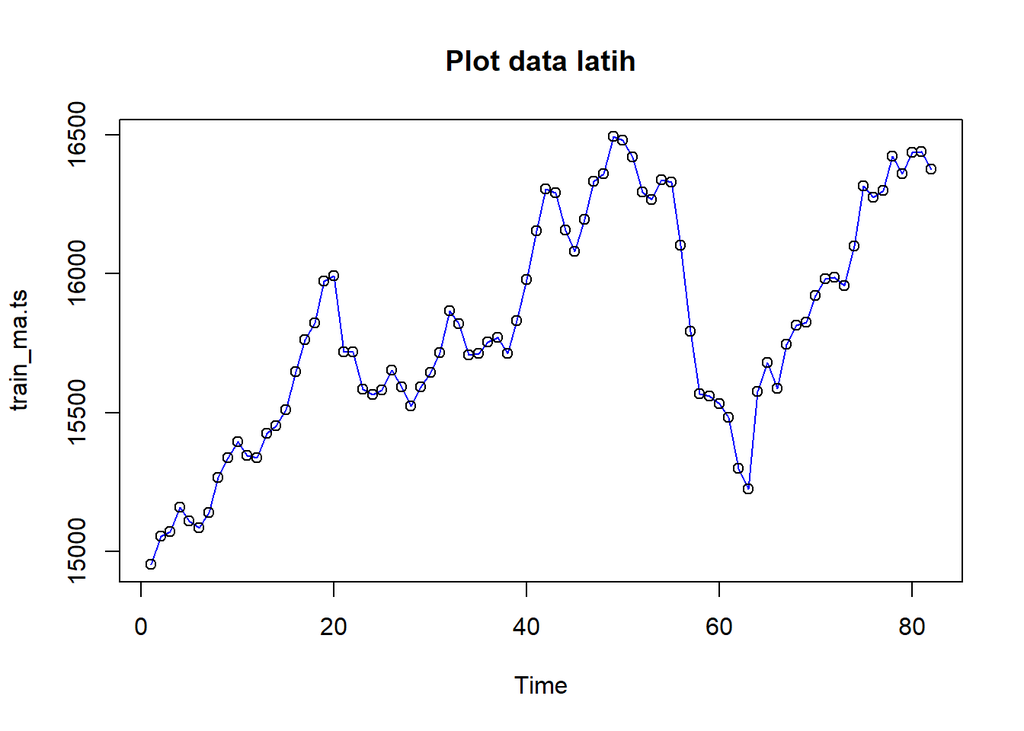

```r
plot(train_ma.ts, col="blue",main="Plot data latih")
points(train_ma.ts)
```

eksplorasi data uji

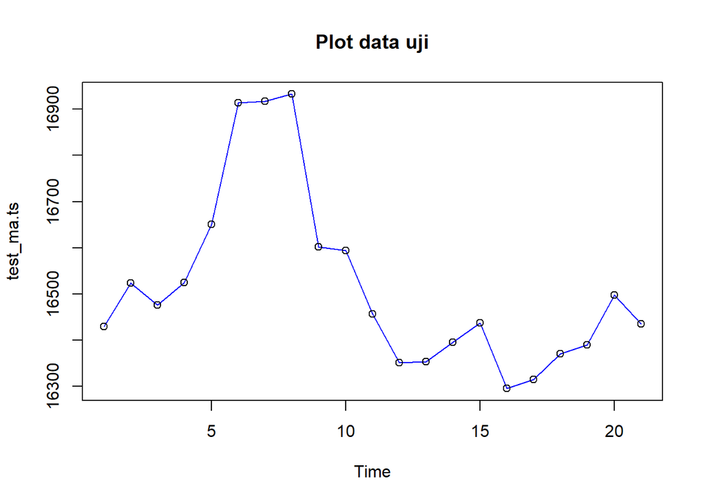

```r
plot(test_ma.ts, col="blue",main="Plot data uji")
points(test_ma.ts)
```

Plot Keseluruhan Data

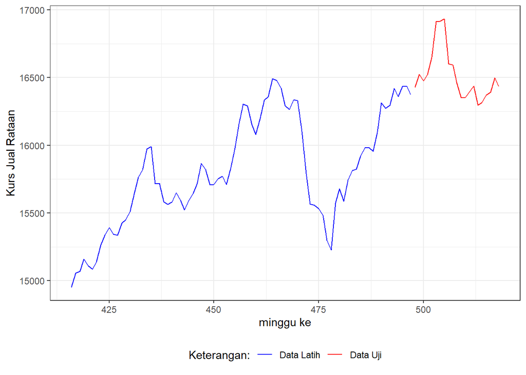

```r
ggplot() +
  geom_line(data = training_ma, aes(x = `Minggu Ke-`, y = `Kurs Jual Rataan`, col = "Data Latih")) +
  geom_line(data = testing_ma, aes(x = `Minggu Ke-`, y = `Kurs Jual Rataan`, col = "Data Uji")) +
  labs(x = "minggu ke", y = "Kurs Jual Rataan", color = "Legend") +
   scale_colour_manual(name="Keterangan:", breaks = c("Data Latih", "Data Uji"),
                      values = c("blue", "red")) +
  theme_bw() + theme(legend.position = "bottom",
                     plot.caption = element_text(hjust=0.5, size=12))
```

```r
data.sma<-SMA(train_ma.ts, n=4)
data.sma
```

```
## Time Series:
## Start = 1
## End = 82
## Frequency = 1
##  [1]       NA       NA       NA 15059.62 15098.97 15106.10 15123.74 15150.02
##  [9] 15206.70 15284.29 15335.50 15353.54 15375.34 15389.61 15430.97 15508.35
## [17] 15593.03 15685.39 15801.11 15887.44 15875.84 15850.26 15752.97 15645.99
## [25] 15611.92 15595.04 15596.75 15586.65 15589.86 15588.10 15618.75 15704.43
## [33] 15761.06 15776.64 15775.94 15747.70 15735.53 15736.74 15766.29 15822.47
## [41] 15918.45 16066.73 16181.76 16226.18 16207.23 16179.60 16190.35 16241.10
## [49] 16344.37 16415.57 16437.28 16421.15 16364.27 16328.69 16306.38 16258.49
## [57] 16140.45 15948.14 15755.08 15612.52 15534.94 15467.85 15384.74 15395.39
## [65] 15444.84 15516.65 15646.39 15706.19 15742.17 15825.78 15884.78 15927.74
## [73] 15960.61 16005.23 16088.64 16160.65 16246.23 16326.83 16338.28 16378.64
## [81] 16413.86 16402.30
```

```r
data.ramal<-c(NA,data.sma)
data.ramal #forecast 1 periode ke depan
```

```
##  [1]       NA       NA       NA       NA 15059.62 15098.97 15106.10 15123.74
##  [9] 15150.02 15206.70 15284.29 15335.50 15353.54 15375.34 15389.61 15430.97
## [17] 15508.35 15593.03 15685.39 15801.11 15887.44 15875.84 15850.26 15752.97
## [25] 15645.99 15611.92 15595.04 15596.75 15586.65 15589.86 15588.10 15618.75
## [33] 15704.43 15761.06 15776.64 15775.94 15747.70 15735.53 15736.74 15766.29
## [41] 15822.47 15918.45 16066.73 16181.76 16226.18 16207.23 16179.60 16190.35
## [49] 16241.10 16344.37 16415.57 16437.28 16421.15 16364.27 16328.69 16306.38
## [57] 16258.49 16140.45 15948.14 15755.08 15612.52 15534.94 15467.85 15384.74
## [65] 15395.39 15444.84 15516.65 15646.39 15706.19 15742.17 15825.78 15884.78
## [73] 15927.74 15960.61 16005.23 16088.64 16160.65 16246.23 16326.83 16338.28
## [81] 16378.64 16413.86 16402.30
```

```r
data.gab<-cbind(
  aktual=c(data.ts),
  pemulusan=c(data.sma,rep(NA,24)),
  ramalan=c(data.ramal,rep(data.ramal[length(data.ramal)],23)))
data.gab #forecast 24 periode ke depan
```

```
##          aktual pemulusan  ramalan
##   [1,] 14952.99        NA       NA
##   [2,] 15055.71        NA       NA
##   [3,] 15070.18        NA       NA
##   [4,] 15159.62  15059.62       NA
##   [5,] 15110.38  15098.97 15059.62
##   [6,] 15084.24  15106.10 15098.97
##   [7,] 15140.73  15123.74 15106.10
##   [8,] 15264.74  15150.02 15123.74
##   [9,] 15337.10  15206.70 15150.02
##  [10,] 15394.59  15284.29 15206.70
##  [11,] 15345.55  15335.50 15284.29
##  [12,] 15336.90  15353.54 15335.50
##  [13,] 15424.34  15375.34 15353.54
##  [14,] 15451.67  15389.61 15375.34
```

[output cut: 92 more lines]

# Plot Hasil Peramalan

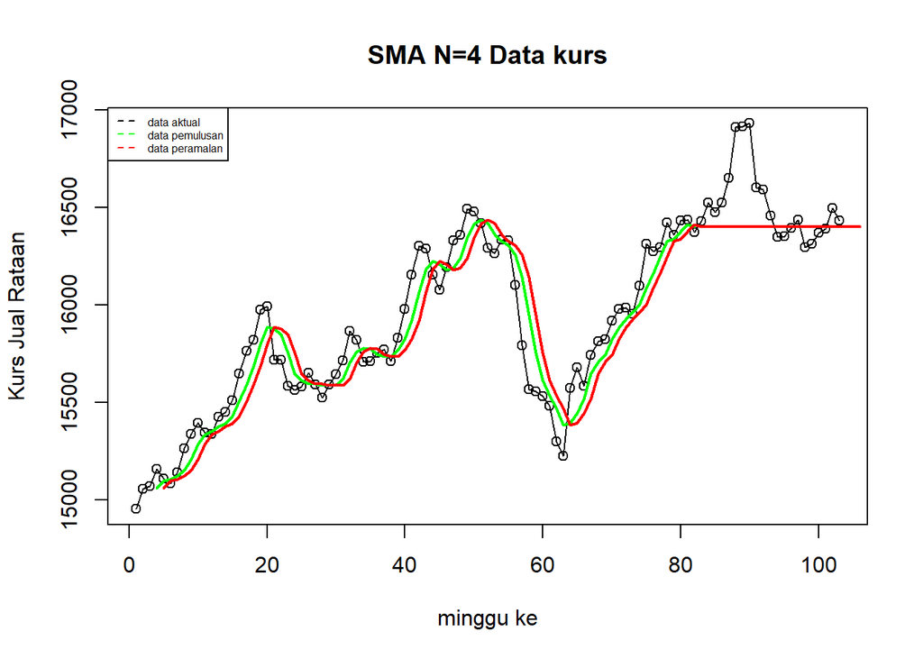

```r
ts.plot(data.ts, xlab="minggu ke", ylab="Kurs Jual Rataan", main= "SMA N=4 Data kurs")
points(data.ts)
lines(data.gab[,2],col="green",lwd=2)
lines(data.gab[,3],col="red",lwd=2)
legend("topleft",c("data aktual","data pemulusan","data peramalan"), lty=8, col=c("black","green","red"), cex=0.5)
```

```r
#Menghitung nilai keakuratan data latih
error_train.sma = train_ma.ts-data.ramal[1:length(train_ma.ts)]

SSE_train.sma = sum(error_train.sma[5:length(train_ma.ts)]^2)
MSE_train.sma = mean(error_train.sma[5:length(train_ma.ts)]^2)
MAPE_train.sma = mean(abs((error_train.sma[5:length(train_ma.ts)]/train_ma.ts[5:length(train_ma.ts)])*100))

akurasi_train.sma <- matrix(c(SSE_train.sma, MSE_train.sma, MAPE_train.sma))
row.names(akurasi_train.sma)<- c("SSE", "MSE", "MAPE")
colnames(akurasi_train.sma) <- c("Akurasi m = 4")
akurasi_train.sma
```

```
##      Akurasi m = 4
## SSE   2.676148e+06
## MSE   3.430959e+04
## MAPE  9.330194e-01
```

MAPE data train pada metode pemulusan SMA sekitar 0,9% ini merupakan nilai akurasi yg cukup tinggi dan dikategorikan sangat baik

```r
# Ambil data aktual (baris 81-104, kolom 1)
actual_test <- data.gab[81:104, 1]

# Ambil data ramalan (baris 81-104, kolom 3)
forecast_test <- data.gab[81:104, 3]

# Hitung error
error_test.sma <- actual_test - forecast_test

# Hitung metrik
SSE_test.sma <- sum(error_test.sma^2)
MSE_test.sma <- mean(error_test.sma^2)
MAPE_test.sma <- mean(abs(error_test.sma / actual_test * 100))

# Simpan dalam matrix
akurasi_test.sma <- matrix(c(SSE_test.sma, MSE_test.sma, MAPE_test.sma))
row.names(akurasi_test.sma) <- c("SSE", "MSE", "MAPE")
colnames(akurasi_test.sma) <- c("Akurasi m = 4")

akurasi_test.sma
```

```
##      Akurasi m = 4
## SSE   3.127276e+06
## MSE   1.303032e+05
## MAPE  1.203045e+00
```

MAPE <10%, Nilai akurasi dikategorikan sangat baik

# Single Exponential Smoothing

Split data 80% Data train & 20% data test

```r
# jumlah baris data
n <- nrow(data)

# hitung batas 80%
n_train <- floor(0.8 * n)

# bagi data
training <- data[1:n_train, ]
testing  <- data[(n_train+1):n, ]

# ubah ke time series
train.ts <- ts(training$`Kurs Jual Rataan`)
test.ts  <- ts(testing$`Kurs Jual Rataan`)
```

Plot Data Train

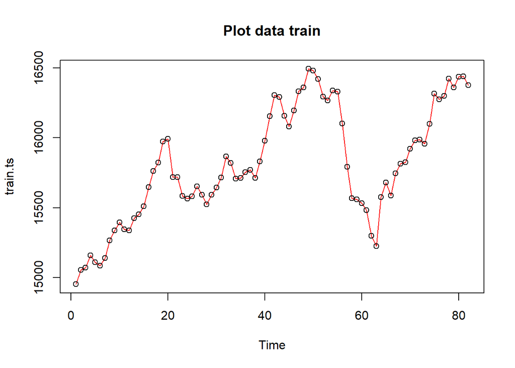

```r
plot(train.ts, col="red",main="Plot data train")
points(train.ts)
```

Plot Data Test

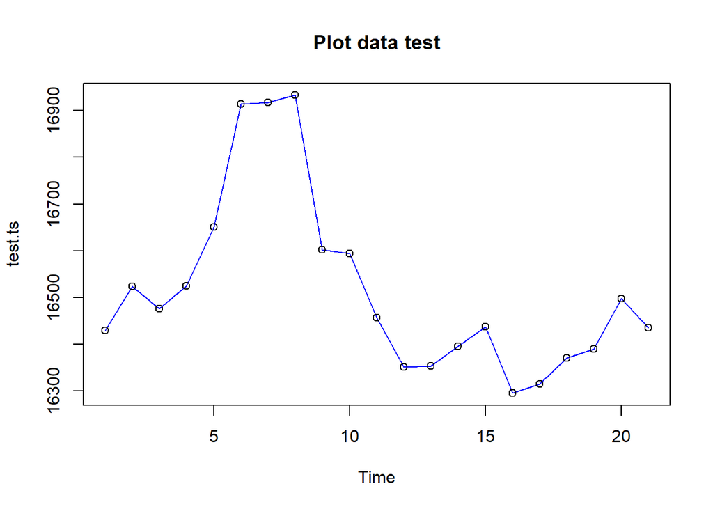

```r
plot(test.ts, col="blue",main="Plot data test")
points(test.ts)
```

Plot Gabungan

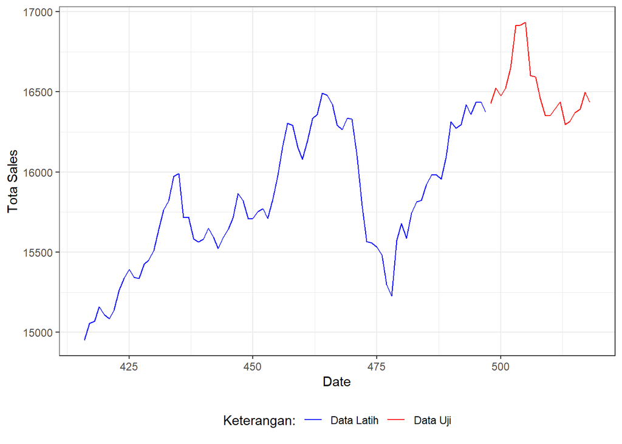

```r
library(ggplot2)
ggplot() +
  geom_line(data = training, aes(x = `Minggu Ke-`, y = `Kurs Jual Rataan`, col = "Data Latih")) +
  geom_line(data = testing, aes(x = `Minggu Ke-`, y = `Kurs Jual Rataan`, col = "Data Uji")) +
  labs(x = "Date", y = "Tota Sales", color = "Legend") +
  scale_colour_manual(name="Keterangan:", breaks = c("Data Latih", "Data Uji"),
                      values = c("blue", "red")) +
  theme_bw() + theme(legend.position = "bottom",
                     plot.caption = element_text(hjust=0.5, size=12))
```

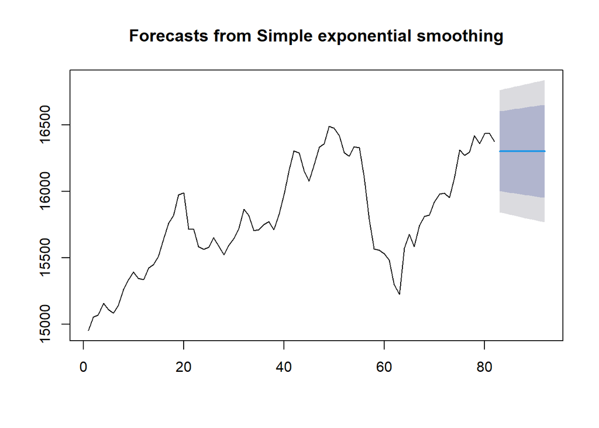

```r
#Cara 1 (fungsi ses)
ses.1 <- ses(train.ts, h = 10, alpha = 0.2)
plot(ses.1)
```

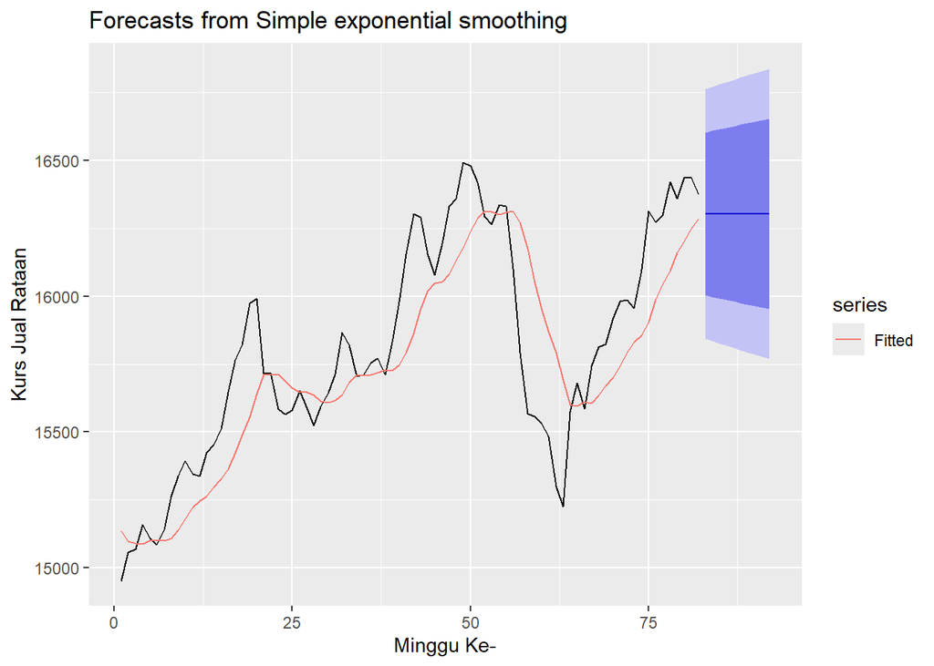

```r
autoplot(ses.1) +
  autolayer(fitted(ses.1), series="Fitted") +
  ylab("Kurs Jual Rataan") + xlab("Minggu Ke-")
```

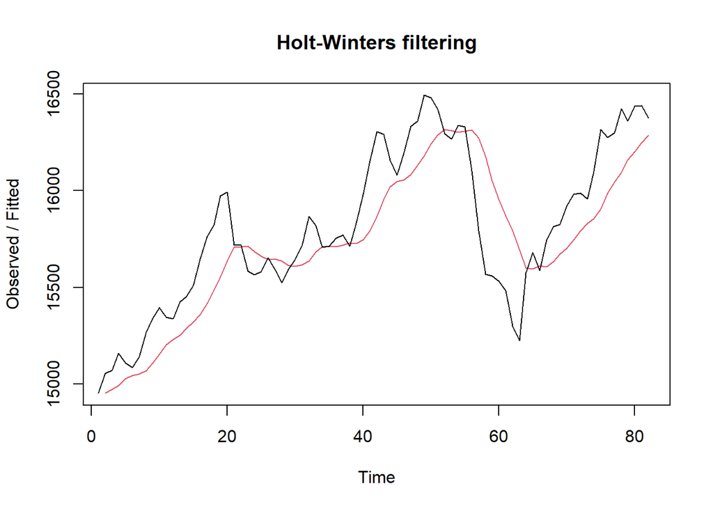

```r
#Cara 2 (fungsi Holtwinter)
ses1<- HoltWinters(train.ts, gamma = FALSE, beta = FALSE, alpha = 0.2)
plot(ses1)
```

```r
#ramalan
ramalan1<- forecast(ses1, h=10)
ramalan1
```

```
##    Point Forecast    Lo 80    Hi 80    Lo 95    Hi 95
## 83       16303.36 16019.98 16586.74 15869.96 16736.76
## 84       16303.36 16014.36 16592.36 15861.38 16745.34
## 85       16303.36 16008.86 16597.86 15852.96 16753.76
## 86       16303.36 16003.45 16603.27 15844.69 16762.03
## 87       16303.36 15998.15 16608.57 15836.58 16770.15
## 88       16303.36 15992.93 16613.79 15828.60 16778.13
## 89       16303.36 15987.80 16618.92 15820.75 16785.97
## 90       16303.36 15982.75 16623.97 15813.03 16793.70
## 91       16303.36 15977.78 16628.94 15805.42 16801.30
## 92       16303.36 15972.88 16633.84 15797.93 16808.79
```

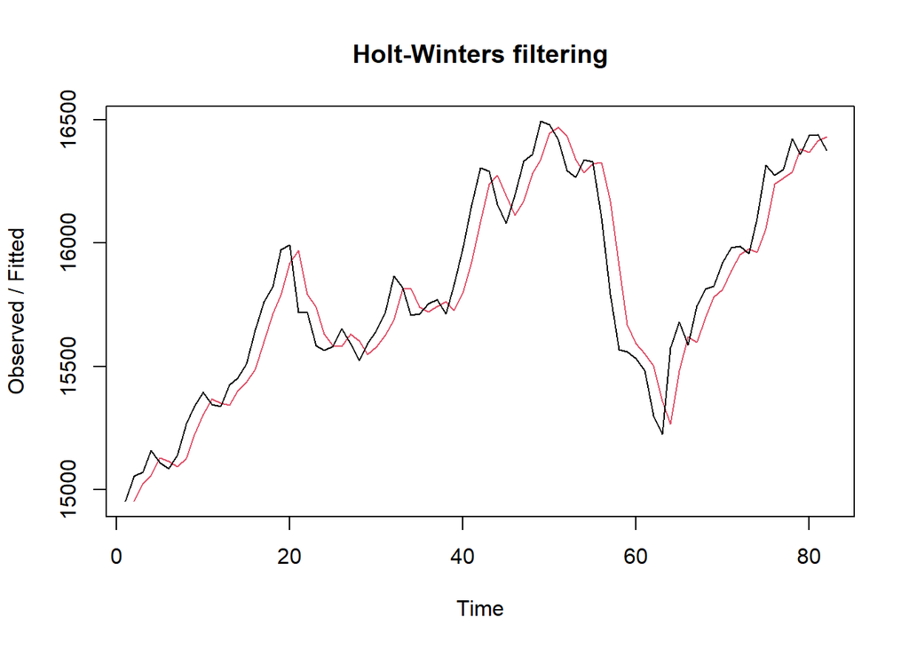

```r
ses2<- HoltWinters(train.ts, gamma = FALSE, beta = FALSE, alpha = 0.7)
plot(ses2)
```

```r
#ramalan
ramalan2<- forecast(ses2, h=10)
ramalan2
```

```
##    Point Forecast    Lo 80    Hi 80    Lo 95    Hi 95
## 83       16392.11 16230.46 16553.76 16144.89 16639.34
## 84       16392.11 16194.79 16589.43 16090.33 16693.89
## 85       16392.11 16164.65 16619.57 16044.23 16739.99
## 86       16392.11 16138.05 16646.17 16003.57 16780.66
## 87       16392.11 16113.99 16670.23 15966.77 16817.45
## 88       16392.11 16091.86 16692.37 15932.91 16851.31
## 89       16392.11 16071.24 16712.98 15901.38 16882.84
## 90       16392.11 16051.87 16732.35 15871.76 16912.46
## 91       16392.11 16033.55 16750.67 15843.74 16940.48
## 92       16392.11 16016.12 16768.10 15817.08 16967.14
```

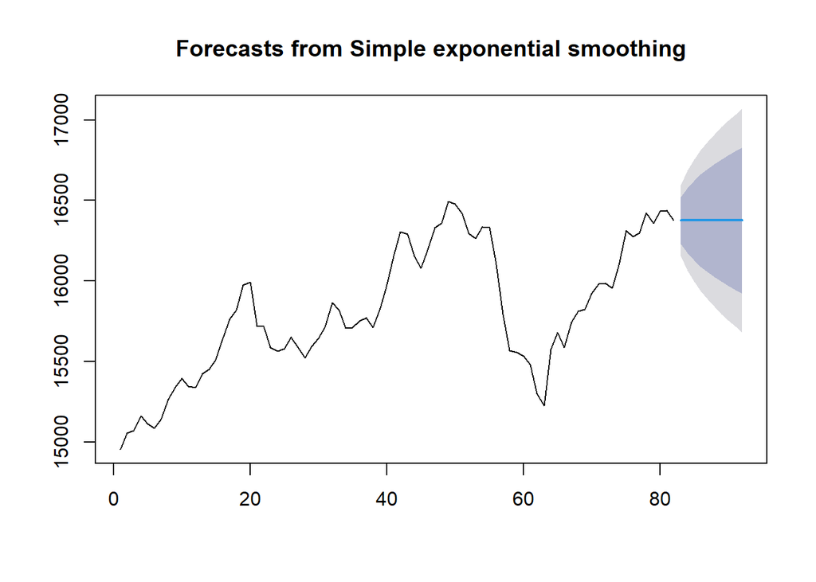

```r
#SES
ses.opt <- ses(train.ts, h = 10, alpha = NULL)
plot(ses.opt)
```

```r
ses.opt
```

```
##    Point Forecast    Lo 80    Hi 80    Lo 95    Hi 95
## 83       16375.27 16231.93 16518.62 16156.04 16594.51
## 84       16375.27 16172.56 16577.99 16065.25 16685.30
## 85       16375.27 16127.00 16623.54 15995.58 16754.97
## 86       16375.27 16088.60 16661.95 15936.84 16813.71
## 87       16375.27 16054.76 16695.79 15885.09 16865.45
## 88       16375.27 16024.17 16726.38 15838.31 16912.24
## 89       16375.27 15996.04 16754.51 15795.29 16955.26
## 90       16375.27 15969.86 16780.69 15755.24 16995.30
## 91       16375.27 15945.27 16805.28 15717.63 17032.91
## 92       16375.27 15922.01 16828.54 15682.06 17068.49
```

```r
#Lamda Optimum Holt Winter
HWopt<- HoltWinters(train.ts, gamma = FALSE, beta = FALSE,alpha = NULL)
HWopt
```

```
## Holt-Winters exponential smoothing without trend and without seasonal component.
##
## Call:
## HoltWinters(x = train.ts, alpha = NULL, beta = FALSE, gamma = FALSE)
##
## Smoothing parameters:
##  alpha: 0.9999325
##  beta : FALSE
##  gamma: FALSE
##
## Coefficients:
##       [,1]
## a 16375.27
```

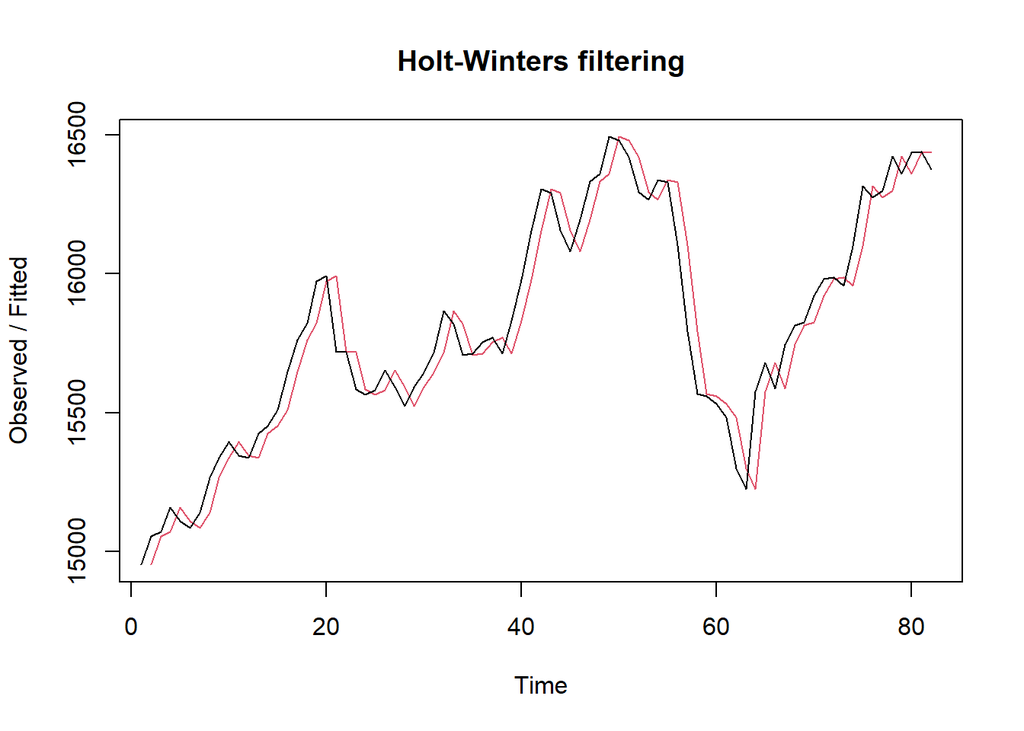

```r
plot(HWopt)
```

```r
#ramalan
ramalanopt<- forecast(HWopt, h=10)
ramalanopt
```

```
##    Point Forecast    Lo 80    Hi 80    Lo 95    Hi 95
## 83       16375.27 16233.73 16516.82 16158.79 16591.75
## 84       16375.27 16175.10 16575.44 16069.14 16681.41
## 85       16375.27 16130.12 16620.43 16000.34 16750.21
## 86       16375.27 16092.19 16658.35 15942.34 16808.21
## 87       16375.27 16058.78 16691.76 15891.24 16859.31
## 88       16375.27 16028.57 16721.97 15845.04 16905.50
## 89       16375.27 16000.80 16749.75 15802.56 16947.99
## 90       16375.27 15974.94 16775.60 15763.02 16987.53
## 91       16375.27 15950.66 16799.89 15725.88 17024.67
## 92       16375.27 15927.69 16822.86 15690.75 17059.79
```

Akurasi Data Train

```r
#Keakuratan Metode
#Pada data training

# SES dengan alpha = 0.2
SSE1<-ses1$SSE
MSE1<-ses1$SSE/length(train.ts)
RMSE1<-sqrt(MSE1)

akurasi1 <- matrix(c(SSE1,MSE1,RMSE1))
row.names(akurasi1)<- c("SSE", "MSE", "RMSE")
colnames(akurasi1) <- c("Akurasi lamda=0.2")
akurasi1
```

```
##      Akurasi lamda=0.2
## SSE       4474549.7215
## MSE         54567.6795
## RMSE          233.5973
```

```r
# SES dengan alpha = 0.7
SSE2<-ses2$SSE
MSE2<-ses2$SSE/length(train.ts)
RMSE2<-sqrt(MSE2)

akurasi2 <- matrix(c(SSE2,MSE2,RMSE2))
row.names(akurasi2)<- c("SSE", "MSE", "RMSE")
colnames(akurasi2) <- c("Akurasi lamda=0.7")
akurasi2
```

```
##      Akurasi lamda=0.7
## SSE        1325035.998
## MSE          16158.976
## RMSE           127.118
```

Akurasi Data Test

```r
# jumlah observasi uji
n_test <- nrow(testing)

# error (ramalan - aktual), samakan panjang dan tipe numeric
e1   <- as.numeric(ramalan1$mean)[1:n_test] - as.numeric(testing$`Kurs Jual Rataan`)
e2   <- as.numeric(ramalan2$mean)[1:n_test] - as.numeric(testing$`Kurs Jual Rataan`)
eopt <- as.numeric(ramalanopt$mean)[1:n_test] - as.numeric(testing$`Kurs Jual Rataan`)

# SSE / MSE / RMSE untuk masing-masing model (abaikan NA)
SSEtesting1  <- sum(e1^2,  na.rm = TRUE)
MSEtesting1  <- mean(e1^2, na.rm = TRUE)
RMSEtesting1 <- sqrt(MSEtesting1)

SSEtesting2  <- sum(e2^2,  na.rm = TRUE)
MSEtesting2  <- mean(e2^2, na.rm = TRUE)
RMSEtesting2 <- sqrt(MSEtesting2)

SSEtestingopt  <- sum(eopt^2,  na.rm = TRUE)
MSEtestingopt  <- mean(eopt^2, na.rm = TRUE)
RMSEtestingopt <- sqrt(MSEtestingopt)

# Tabel ringkas
akurasitesting_SSE <- matrix(c(SSEtesting1, SSEtesting2, SSEtestingopt),
                             nrow = 3,
                             dimnames = list(c("SSE1","SSE2","SSEopt"), "Nilai"))
akurasitesting_MSE <- matrix(c(MSEtesting1, MSEtesting2, MSEtestingopt),
                             nrow = 3,
                             dimnames = list(c("MSE1","MSE2","MSEopt"), "Nilai"))
akurasitesting_RMSE <- matrix(c(RMSEtesting1, RMSEtesting2, RMSEtestingopt),
                              nrow = 3,
                              dimnames = list(c("RMSE1","RMSE2","RMSEopt"), "Nilai"))

akurasitesting_SSE
```

```
##          Nilai
## SSE1   1582733
## SSE2   1034800
## SSEopt 1126649
```

SSEopt model yg optimal hampir sama dengan SSE2 maka model 2 sudah cukup bagus

```r
akurasitesting_MSE
```

```
##           Nilai
## MSE1   158273.3
## MSE2   103480.0
## MSEopt 112664.9
```

```r
akurasitesting_RMSE
```

```
##            Nilai
## RMSE1   397.8357
## RMSE2   321.6831
## RMSEopt 335.6560
```

artinya pada ketiga model ini rata2 error per prediksi sekitar 300an Model 1 Jauh lebih buruk krn rata2 error hampir mendekati 400

# Kesimpulan

Model 2 memberikan hasil yg terbaik dengan tingkat error terendah

Model 1 jauh lebih buruk Karena SSE, MSE, RMSE lebih besar.

Model optimal (SSEopt/MSEopt/RMSEopt) hampir sama dengan Model 2, artinya tuning parameter tidak banyak memperbaiki performa, maka Model 2 sudah cukup baik.

Dari sudut pandang praktis, model terbaik menghasilkan error rata-rata sekitar bernilai 300an Kurs jual rataan setiap minggu.